# Principal Component Analysis

Adham Suliman

July 19, 2018

Part 2

1. Q: Split the sample into two random samples sizes 70% and 30%.
2. Q: Perform prinicipal components of variables 1:7 from the GermanCredit Data on training sample.

```r
data(GermanCredit)
GermanCredit <- data.frame(scale(GermanCredit[,1:7]))
german.credit.train_ind <- sample(1:(nrow(GermanCredit)),700)
german.credit_1to7.train <- data.frame(scale(GermanCredit[german.credit.train_ind,]))
german.credit_1to7.mean <- apply(german.credit_1to7.train,2,mean)
german.credit_1to7.sd <- apply(german.credit_1to7.train,2,sd)
german.credit_1to7.train <- (german.credit_1to7.train-german.credit_1to7.mean)/german.credit_1to7.sd
x = prcomp(german.credit_1to7.train)
```

3. Generate Scree Plots and select number of components you would retain. From the scree plot below, we can see the “elbow” at around 6 Loadings which means we will keep 6 loadings for our analysis.

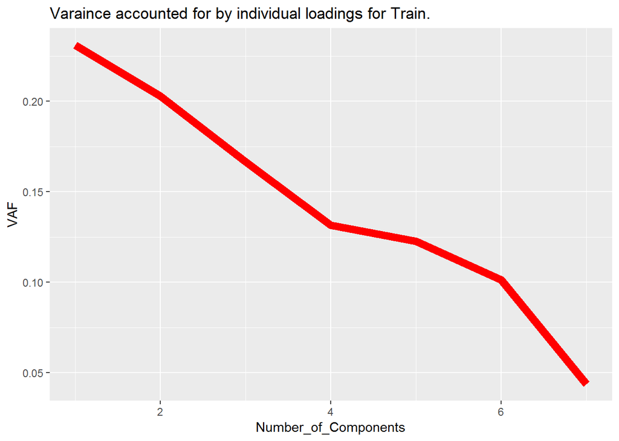

```r
cum.VAF.gm1 <- data.frame("Number_of_Components" = c(seq(1,7)), "VAF" = (c(x$sdev^2)/sum(x$sdev^2)))
ggplot(cum.VAF.gm1, aes(x=Number_of_Components, y=VAF, colours = VAF))  + ggtitle("Varaince accounted for by individual loadings for Train.") + geom_line(data = cum.VAF.gm1, aes(x=Number_of_Components, y=VAF), color = 'red', size = 3)
```

Q4) Plot component 1 loadings (x-axis) versus Component 2 loadings (y-axis). Use this plot to interpret and name the components.

For the 1st component against the the 4th component,we can see that Number of Existing Credits, Duration, Number of People Maintenance and Duration are all favorable to component 4 while Age and Duration of Residence are unfavorable towards Component 4.

For the 1st component against the 5th, The only parameter that is favorable in the 5th component is Number of Existing credits. Duration, Intallment Rater Percentage, and Number of People Maintenance are all unfavorable towards the 5th component.

For the 1st component against the 6th, The only parameter that is favorable to the 6th component is Duraiton of Residence while Age has an unfavorable effect on the 6th component.

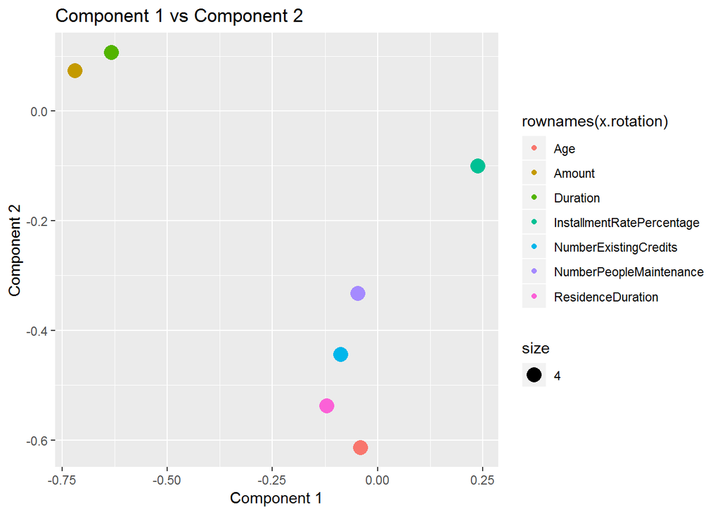

```r
x.rotation<-data.frame(x$rotation)
ggplot(x.rotation, aes(x=x.rotation[,1], y= x.rotation[,2], colour = rownames(x.rotation), size =4)) + geom_point() + xlab("Component 1") + ylab("Component 2") + ggtitle("Component 1 vs Component 2")
```

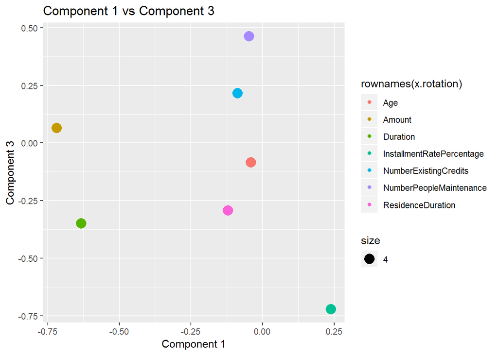

```r
ggplot(x.rotation, aes(x=x.rotation[,1], y= x.rotation[,3], colour = rownames(x.rotation), size =4)) + geom_point()  + xlab("Component 1") + ylab("Component 3") + ggtitle("Component 1 vs Component 3")
```

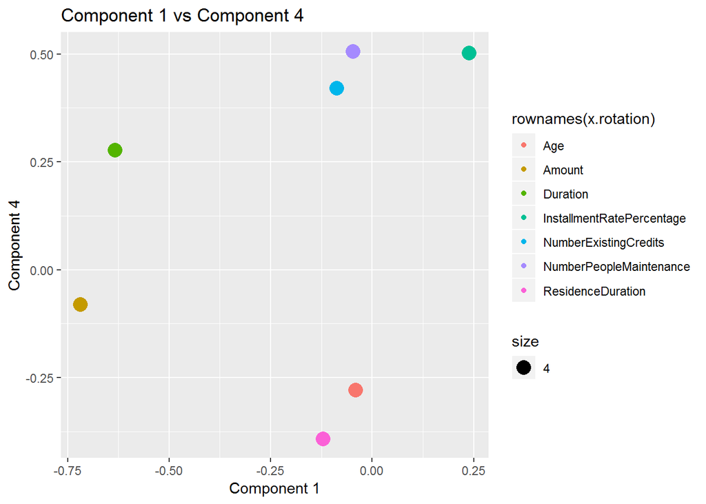

```r
ggplot(x.rotation, aes(x=x.rotation[,1], y= x.rotation[,4], colour = rownames(x.rotation), size =4)) + geom_point()  + xlab("Component 1") + ylab("Component 4") + ggtitle("Component 1 vs Component 4")
```

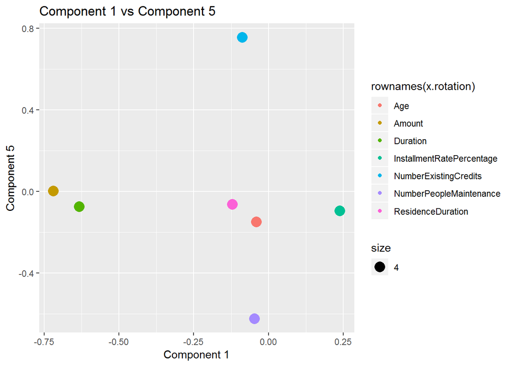

```r
ggplot(x.rotation, aes(x=x.rotation[,1], y= x.rotation[,5], colour = rownames(x.rotation), size =4)) + geom_point()  + xlab("Component 1") + ylab("Component 5") + ggtitle("Component 1 vs Component 5")
```

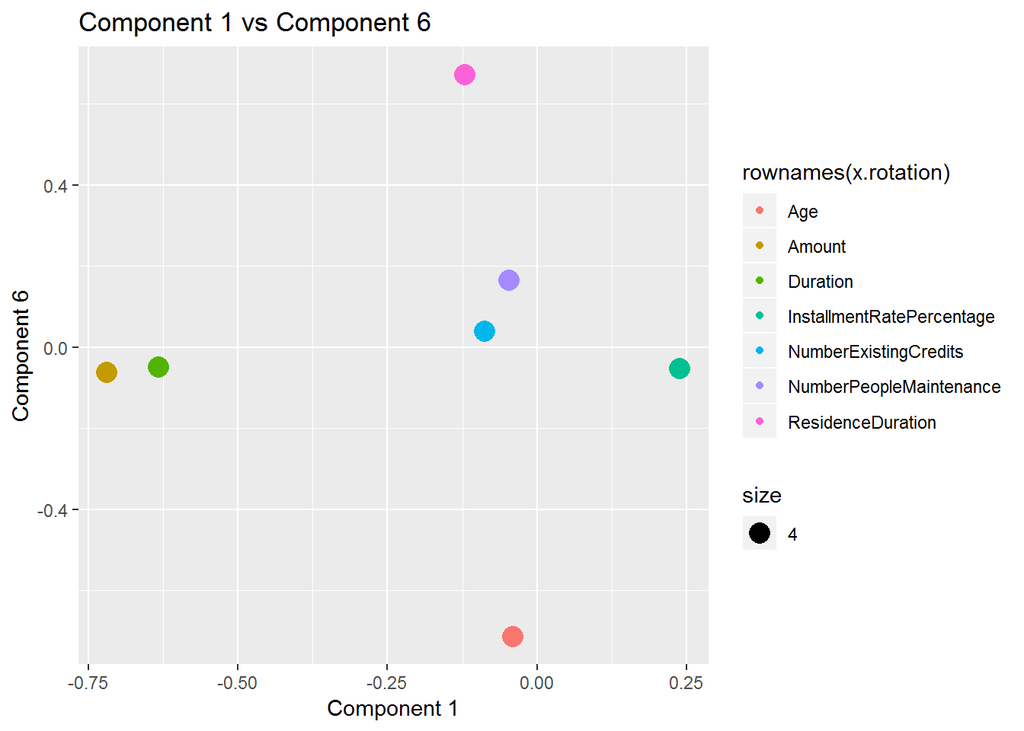

```r
ggplot(x.rotation, aes(x=x.rotation[,1], y= x.rotation[,6], colour = rownames(x.rotation), size =4)) + geom_point()  + xlab("Component 1") + ylab("Component 6") + ggtitle("Component 1 vs Component 6")
```

Q5) Show that eigenvectors are orthogonal

```r
round(t(x$rotation) %*% x$rotation,0)
```

```
##     PC1 PC2 PC3 PC4 PC5 PC6 PC7
## PC1   1   0   0   0   0   0   0
## PC2   0   1   0   0   0   0   0
## PC3   0   0   1   0   0   0   0
## PC4   0   0   0   1   0   0   0
## PC5   0   0   0   0   1   0   0
## PC6   0   0   0   0   0   1   0
## PC7   0   0   0   0   0   0   1
```

Q6) Show that component scores are orthogonal ?????

```r
round(cov(x$x),2)
```

```
##      PC1  PC2  PC3  PC4  PC5  PC6  PC7
## PC1 1.62 0.00 0.00 0.00 0.00 0.00 0.00
## PC2 0.00 1.42 0.00 0.00 0.00 0.00 0.00
## PC3 0.00 0.00 1.17 0.00 0.00 0.00 0.00
## PC4 0.00 0.00 0.00 0.92 0.00 0.00 0.00
## PC5 0.00 0.00 0.00 0.00 0.86 0.00 0.00
## PC6 0.00 0.00 0.00 0.00 0.00 0.71 0.00
## PC7 0.00 0.00 0.00 0.00 0.00 0.00 0.31
```

7. & 8) Perform holdout validation of principal component solution and compute Varriance Account for in the Holdout Sample There is a high correlation of .96 as seen below.

```r
german.Credit_1to7.test <- scale(data.frame(GermanCredit[-german.credit.train_ind,]),
                                 center = colMeans(german.credit_1to7.train),
                                 scale = apply(german.credit_1to7.train, 2, sd))
y=predict(x, newdata = german.Credit_1to7.test)
manual.set <- y[,1:6]%*%t((x$rotation[,1:6]))
round(cor(as.vector(manual.set),as.vector(german.Credit_1to7.test))^2,2)
```

```
## [1] 0.96
```

9. Rotate the component loadings using varimax rotation.

```r
x$rotation[,1:6]
```

```
##                                   PC1         PC2         PC3         PC4          PC5         PC6
## Duration                  -0.63253206  0.10685819 -0.34867935  0.27739745 -0.074340831 -0.04947292
## Amount                    -0.71902875  0.07285184  0.06469831 -0.08078778  0.001618287 -0.06231828
## InstallmentRatePercentage  0.23854726 -0.10069879 -0.72077404  0.50224324 -0.095300498 -0.05383466
## ResidenceDuration         -0.12020040 -0.53747389 -0.29341408 -0.39149860 -0.063630926  0.67273375
## Age                       -0.04034031 -0.61363284 -0.08499938 -0.27928601 -0.149984747 -0.71387275
## NumberExistingCredits     -0.08772075 -0.44403815  0.21569234  0.42038838  0.755087485  0.03916202
## NumberPeopleMaintenance   -0.04717676 -0.33247611  0.46355336  0.50623857 -0.623447839  0.16447500
```

```r
y1=varimax(x$rotation[,1:6])
y1$loadings
```

```
##
## Loadings:
##                           PC1    PC2    PC3    PC4    PC5    PC6
## Duration                  -0.740        -0.261
## Amount                    -0.673         0.285
## InstallmentRatePercentage               -0.922
## ResidenceDuration                                             1.000
## Age                              -0.998
## NumberExistingCredits                                  1.000
## NumberPeopleMaintenance                         1.000
##
##                  PC1   PC2   PC3   PC4   PC5   PC6
## SS loadings    1.000 1.000 1.000 1.000 1.000 1.000
## Proportion Var 0.143 0.143 0.143 0.143 0.143 0.143
## Cumulative Var 0.143 0.286 0.429 0.571 0.714 0.857
```

10. Plot rotated loadings(1) versus rotated loadings (2) and (3). Do you think Principal Components reduced this data a lot? Do you like the solution?

The verimax function has proven itself incredibly useful within this excercise.

For the 1st component against the 2nd component, the verimax function has minimized the 2nd component’s minor to medium effects on Installment Rate Percentage, Number of People Maintenance, Number of Existing Credits, and Duration of Residence while maximizing the ngative effect of Age from -.6 to -1.

The 1st component didn’t seem to change much with the verimax funciton.

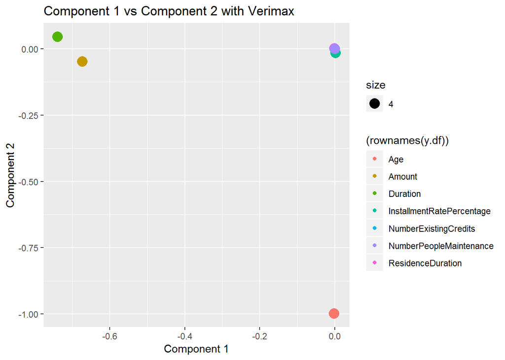

```r
y.df<-data.frame(matrix(y1$loadings[,1:3], byrow = F, ncol = 3),row.names = rownames((y1$loadings)[,1:3]))
ggplot(y.df,aes(x=(y.df[,1]),y=y.df[,2], colour=(rownames(y.df)), size = 4)) + geom_point() + xlab('Component 1') + ylab('Component 2') + ggtitle("Component 1 vs Component 2 with Verimax")
```

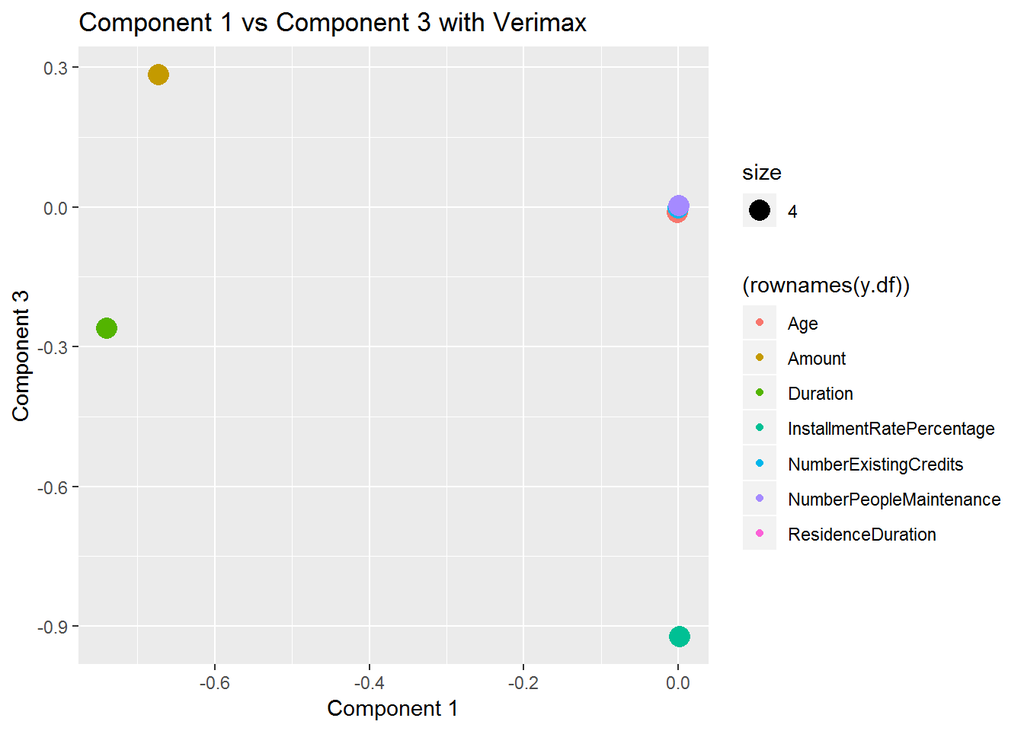

```r
ggplot(y.df,aes(x=(y.df[,1]),y=y.df[,3], colour=(rownames(y.df)), size = 4)) + geom_point() + xlab('Component 1') + ylab('Component 3') + ggtitle("Component 1 vs Component 3 with Verimax")
```

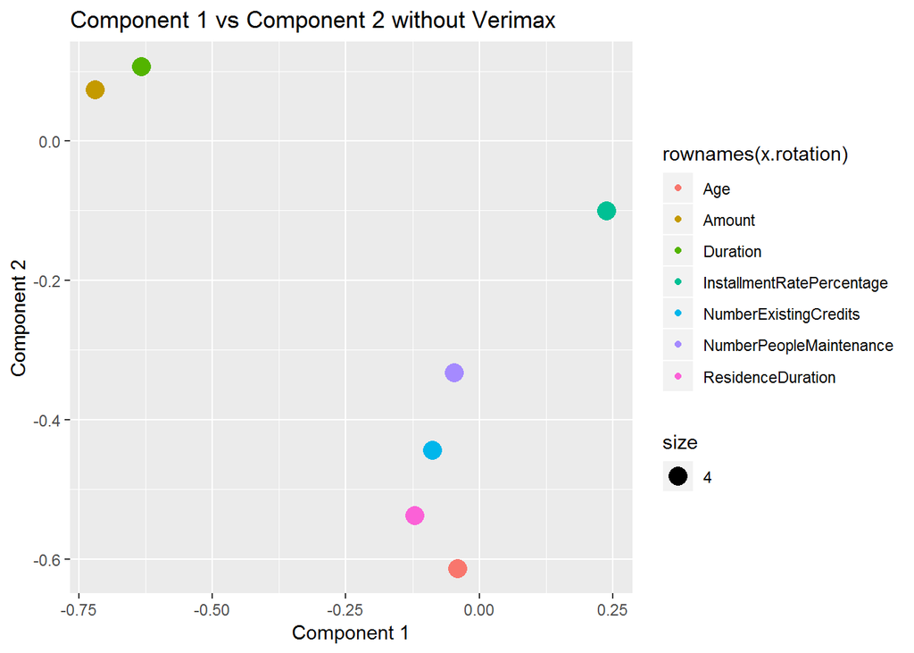

```r
ggplot(x.rotation, aes(x=x.rotation[,1], y= x.rotation[,2], colour = rownames(x.rotation), size =4)) + geom_point() + xlab("Component 1") + ylab("Component 2") + ggtitle("Component 1 vs Component 2 without Verimax")
```

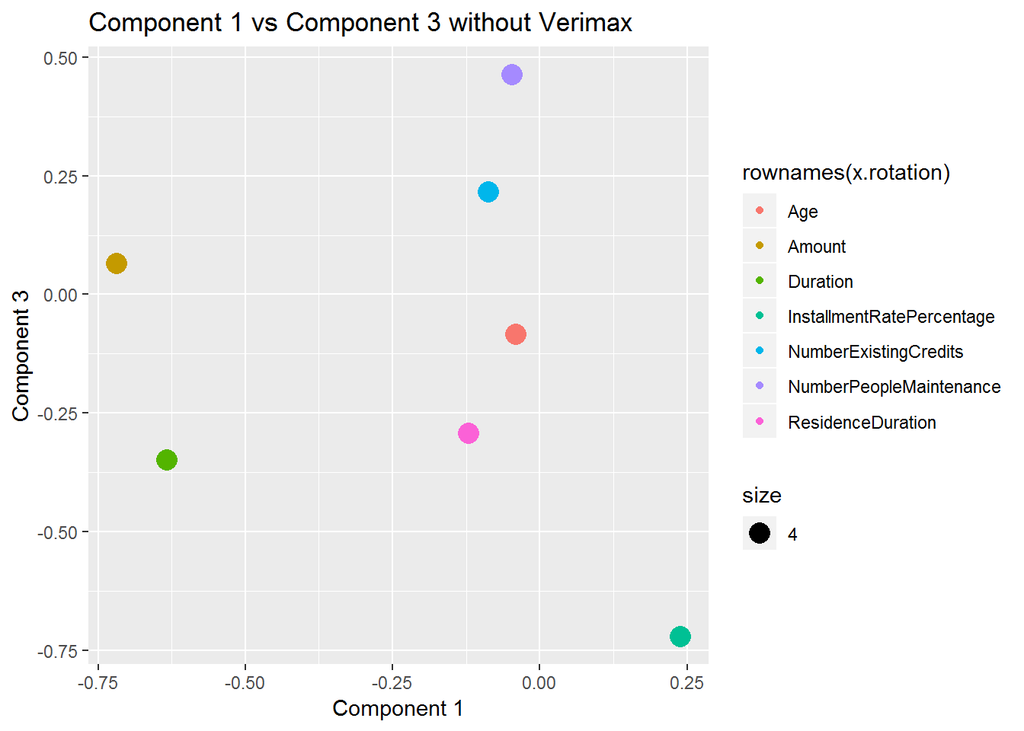

```r
ggplot(x.rotation, aes(x=x.rotation[,1], y= x.rotation[,3], colour = rownames(x.rotation), size =4)) + geom_point() + xlab("Component 1") + ylab("Component 3") + ggtitle("Component 1 vs Component 3 without Verimax")
```